# D2Hawkeye

Mohammed Ali

July 15, 2018

# Data Setup

Read data and split it to train and test datasets

```r
Claims <- read.csv("data/ClaimsData.csv")
glimpse(Claims)
```

```
## Observations: 458,005
## Variables: 16
## $ age               <int> 85, 59, 67, 52, 67, 68, 75, 70, 67, 67, 89, ...
## $ alzheimers        <int> 0, 0, 0, 0, 0, 0, 0, 0, 0, 0, 0, 0, 0, 0, 0,...
## $ arthritis         <int> 0, 0, 0, 0, 0, 0, 0, 0, 0, 0, 0, 0, 0, 0, 0,...
## $ cancer            <int> 0, 0, 0, 0, 0, 0, 0, 0, 0, 0, 0, 0, 0, 0, 0,...
## $ copd              <int> 0, 0, 0, 0, 0, 0, 0, 0, 0, 0, 0, 0, 0, 0, 0,...
## $ depression        <int> 0, 0, 0, 0, 0, 0, 0, 0, 0, 0, 0, 0, 0, 0, 0,...
## $ diabetes          <int> 0, 0, 0, 0, 0, 0, 0, 0, 0, 0, 0, 0, 0, 0, 0,...
## $ heart.failure     <int> 0, 0, 0, 0, 0, 0, 0, 0, 0, 0, 0, 0, 0, 0, 0,...
## $ ihd               <int> 0, 0, 0, 0, 0, 0, 0, 0, 0, 0, 0, 0, 0, 0, 0,...
## $ kidney            <int> 0, 0, 0, 0, 0, 0, 0, 0, 0, 0, 0, 0, 0, 0, 0,...
## $ osteoporosis      <int> 0, 0, 0, 0, 0, 0, 0, 0, 0, 0, 0, 0, 0, 0, 0,...
## $ stroke            <int> 0, 0, 0, 0, 0, 0, 0, 0, 0, 0, 0, 0, 0, 0, 0,...
## $ reimbursement2008 <int> 0, 0, 0, 0, 0, 0, 0, 0, 0, 0, 0, 0, 0, 0, 0,...
## $ bucket2008        <int> 1, 1, 1, 1, 1, 1, 1, 1, 1, 1, 1, 1, 1, 1, 1,...
## $ reimbursement2009 <int> 0, 0, 0, 0, 0, 0, 0, 0, 0, 0, 0, 0, 0, 0, 0,...
## $ bucket2009        <int> 1, 1, 1, 1, 1, 1, 1, 1, 1, 1, 1, 1, 1, 1, 1,...
```

Now let us see the percentage of patients in each cost bucket

```
##
##           1           2           3           4           5
## 0.671267781 0.190170413 0.089466272 0.043324855 0.005770679
```

Split the data

```r
set.seed(88)

spl <- sample.split(Claims$bucket2009, SplitRatio = 0.6)

ClaimsTrain <- subset(Claims, spl==TRUE)

ClaimsTest <- subset(Claims, spl==FALSE)
```

let us do some investigations

What is the average age of patients in the training set, ClaimsTrain?

```r
mean(ClaimsTrain$age)
```

```
## [1] 72.63773
```

What proportion of people in the training set (ClaimsTrain) had at least one diagnosis code for diabetes?

```r
table(ClaimsTrain$diabetes)["1"] / nrow(ClaimsTrain)
```

```
##         1
## 0.3808983
```

# Baseline Method and Penalty Matrix

Baseline method is to predicat that the predicated values for 2009 are the same as 2008

```r
table(ClaimsTest$bucket2009, ClaimsTest$bucket2008)
```

```
##
##          1      2      3      4      5
##   1 110138   7787   3427   1452    174
##   2  16000  10721   4629   2931    559
##   3   7006   4629   2774   1621    360
##   4   2688   1943   1415   1539    352
##   5    293    191    160    309    104
```

```r
(110138 + 10721 + 2774 + 1539 + 104)/nrow(ClaimsTest)
```

```
## [1] 0.6838135
```

Penalty Matrix

```r
PenaltyMatrix = matrix(c(0,1,2,3,4,2,0,1,2,3,4,2,0,1,2,6,4,2,0,1,8,6,4,2,0), byrow=TRUE, nrow=5)

PenaltyMatrix
```

```
##      [,1] [,2] [,3] [,4] [,5]
## [1,]    0    1    2    3    4
## [2,]    2    0    1    2    3
## [3,]    4    2    0    1    2
## [4,]    6    4    2    0    1
## [5,]    8    6    4    2    0
```

Penalty Error of Baseline Method

```r
as.matrix(table(ClaimsTest$bucket2009, ClaimsTest$bucket2008))*PenaltyMatrix
```

```
##
##         1     2     3     4     5
##   1     0  7787  6854  4356   696
##   2 32000     0  4629  5862  1677
##   3 28024  9258     0  1621   720
##   4 16128  7772  2830     0   352
##   5  2344  1146   640   618     0
```

```r
sum(as.matrix(table(ClaimsTest$bucket2009, ClaimsTest$bucket2008))*PenaltyMatrix)/nrow(ClaimsTest)
```

```
## [1] 0.7386055
```

Suppose that instead of the baseline method discussed above, we used the baseline method of predicting the most frequent outcome for all observations. This new baseline method would predict cost bucket 1 for everyone.

What would the accuracy of this baseline method be on the test set?

To compute the accuracy, you can create a table of the variable `ClaimsTest$bucket2009`

```r
table(ClaimsTest$bucket2009)["1"]/nrow(ClaimsTest)
```

```
##       1
## 0.67127
```

What would the penalty error of this baseline method be on the test set?

For the penalty error, since this baseline method predicts 1 for all observations, it would have a penalty error of:

```r
sum(table(ClaimsTest$bucket2009) * c(0, 2, 4, 6, 8))/nrow(ClaimsTest)
```

```
## [1] 1.044301
```

# Predicting Healthcare Costs

## CART model

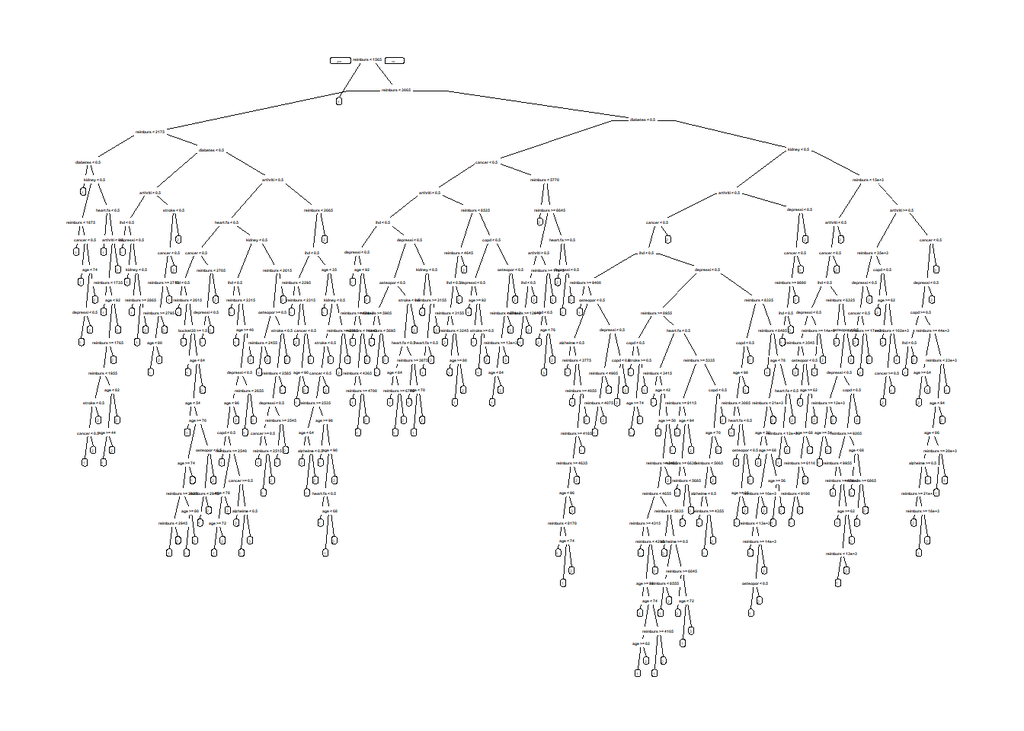

```r
ClaimsTree <- rpart(bucket2009 ~ age + alzheimers + arthritis + cancer + copd + depression + diabetes + heart.failure + ihd + kidney + osteoporosis + stroke + bucket2008 + reimbursement2008, data=ClaimsTrain, method="class", cp=0.00005)
prp(ClaimsTree)
```

## Make predictions

```r
PredictTest <- predict(ClaimsTree, newdata = ClaimsTest, type = "class")

table(ClaimsTest$bucket2009, PredictTest)
```

```
##    PredictTest
##          1      2      3      4      5
##   1 114141   8610    124    103      0
##   2  18409  16102    187    142      0
##   3   8027   8146    118     99      0
##   4   3099   4584     53    201      0
##   5    351    657      4     45      0
```

```r
(114141 + 16102 + 118 + 201 + 0)/nrow(ClaimsTest)
```

```
## [1] 0.7126669
```

## Penalty Error

```r
as.matrix(table(ClaimsTest$bucket2009, PredictTest))*PenaltyMatrix
```

```
##    PredictTest
##         1     2     3     4     5
##   1     0  8610   248   309     0
##   2 36818     0   187   284     0
##   3 32108 16292     0    99     0
##   4 18594 18336   106     0     0
##   5  2808  3942    16    90     0
```

```r
sum(as.matrix(table(ClaimsTest$bucket2009, PredictTest))*PenaltyMatrix)/nrow(ClaimsTest)
```

```
## [1] 0.7578902
```

## New CART model with loss matrix

```r
ClaimsTree <- rpart(bucket2009 ~ age + alzheimers + arthritis + cancer + copd + depression + diabetes + heart.failure + ihd + kidney + osteoporosis + stroke + bucket2008 + reimbursement2008, data=ClaimsTrain, method="class", cp=0.00005, parms=list(loss=PenaltyMatrix))
```

## Redo predictions and penalty error

```r
PredictTest = predict(ClaimsTree, newdata = ClaimsTest, type = "class")

table(ClaimsTest$bucket2009, PredictTest)
```

```
##    PredictTest
##         1     2     3     4     5
##   1 94310 25295  3087   286     0
##   2  7176 18942  8079   643     0
##   3  3590  7706  4692   401     1
##   4  1304  3193  2803   636     1
##   5   135   356   408   156     2
```

```r
(94310 + 18942 + 4692 + 636 + 2)/nrow(ClaimsTest)
```

```
## [1] 0.6472746
```

```r
sum(as.matrix(table(ClaimsTest$bucket2009, PredictTest))*PenaltyMatrix)/nrow(ClaimsTest)
```

```
## [1] 0.6418161
```